# Modern Data Mining - HW 3

Antina Lee

Joey Haymaker

Maria Diaz Ortiz

## Overview / Instructions

This is homework #3 of STAT 471/571/701. It will be **due on 22 October, 2017 by 11:59 PM** on Canvas. You can directly edit this file to add your answers. Submit the Rmd file, a PDF or word or HTML version with only 1 submission per HW team.

**Note:** To minimize your work and errors, we provide this Rmd file to guide you in the process of building your final report. To that end, we’ve included code to load the necessary data files. Make sure that the following files are in the same folder as this R Markdown file:

- `FRAMINGHAM.dat`
- `Bills.subset.csv`
- `Bills.subset.test.csv`

The data should load properly if you are working in Rstudio, *without needing to change your working directory*.

Solutions will be posted. Make sure to compare your answers to and understand the solutions. ## Problem 0

Review the code and concepts covered during lecture, in particular, logistic regression and classification.

```r
#knitr::opts_chunk$set(echo = TRUE, results = "hide", fig.width=6, fig.height=4)
if(!require('pacman')) {
  install.packages('pacman')
}
#library(pacman)
library(bestglm)
library(ggplot2)
library(dplyr)
library(leaps)
pacman::p_load(pROC, leaps, car, tidyverse, mapproj, caret)
```

## Problem 1

We will continue to use the Framingham Data (`Framingham.dat`) so that you are already familiar with the data and the variables. All the results are obtained through training data.

To keep our answers consistent, use a subset of the data, and exclude anyone with a missing entry. For your convenience, we’ve loaded it here together with a brief summary about the data.

We note that this dataset contains 311 people diagnosed with heart disease and 1095 without heart disease.

```
     0    1
  1095  311
```

After a quick cleaning up here is a summary about the data:

```r
# using the comment="     ", we get rid of the ## in the output.
summary(hd_data.f)
```

```
       HD            AGE            SEX           SBP             DBP
       0:1086   Min.   :45.00   FEMALE:730   Min.   : 90.0   Min.   : 50.00
       1: 307   1st Qu.:48.00   MALE  :663   1st Qu.:130.0   1st Qu.: 80.00
                Median :52.00                Median :142.0   Median : 90.00
                Mean   :52.43                Mean   :148.1   Mean   : 90.16
                3rd Qu.:56.00                3rd Qu.:160.0   3rd Qu.: 98.00
                Max.   :62.00                Max.   :300.0   Max.   :160.00
            CHOL            FRW             CIG
       Min.   : 96.0   Min.   : 52.0   Min.   : 0.000
       1st Qu.:200.0   1st Qu.: 94.0   1st Qu.: 0.000
       Median :230.0   Median :103.0   Median : 0.000
       Mean   :234.6   Mean   :105.4   Mean   : 8.035
       3rd Qu.:264.0   3rd Qu.:114.0   3rd Qu.:20.000
       Max.   :430.0   Max.   :222.0   Max.   :60.000
```

### Part 1A

Goal: Identify important risk factors for `Heart.Disease.` through logistic regression. Start a fit with just one factor, `SBP`, and call it `fit1`. Let us add one variable to this at a time from among the rest of the variables.

```r
tapply(hd_data$SBP, hd_data$HD, mean)
fit1 <- glm(HD~SBP, hd_data.f, family=binomial)
summary(fit1)
fit1.1 <- glm(HD~SBP + AGE, hd_data.f, family=binomial)
summary(fit1.1)
fit1.2 <- glm(HD~SBP + SEX, hd_data.f, family=binomial)
summary(fit1.2)
fit1.3 <- glm(HD~SBP + DBP, hd_data.f, family=binomial)
summary(fit1.3)
fit1.4 <- glm(HD~SBP + CHOL, hd_data.f, family=binomial)
summary(fit1.4)
fit1.5 <- glm(HD~SBP + DBP, hd_data.f, family=binomial)
summary(fit1.5)
fit1.6 <- glm(HD~SBP + FRW, hd_data.f, family=binomial)
summary(fit1.6)
fit1.7 <- glm(HD~SBP + CIG, hd_data.f, family=binomial)
summary(fit1.7)
```

1. Which single variable would be the most important to add? Add it to your model, and call the new fit `fit2`.

We will pick up the variable either with highest $|z|$ value, or smallest $p$ value. From all the two variable models we see that `SEX` will be the most important addition on top of the SBP. And here is the summary report.

```r
## How to control the summary(fit2) output to cut some junk?
## We could use packages: xtable or broom.
#install.packages("xtable")
library(xtable)
options(xtable.comment = FALSE)
fit2 <- glm(HD~SBP + SEX, hd_data.f, family=binomial)
xtable(fit2)
```

2. Is the residual deviance of `fit2` always smaller than that of `fit1`? Why or why not?

It will always be smaller, since fit 2 contains the variables in fit 1 (so similar to RSS, it goes down as you add more variables).

3. Perform both the Wald test and the Likelihood ratio tests (Chi-Squared) to see if the added variable is significant at the .01 level. What are the p-values from each test? Are they the same?

The following code performs the Wald and Chi-Squared Tests:

```r
#Wald Test/Intervals
summary(fit2)
confint.default(fit2)
#pval for SEXMALE = 1.02e-10
#CI's for SEXMALE = [0.62949139 1.17734896]
#Added variable is significant at the 0.01 level

#Chi-Squared Test
anova(fit2, test="Chisq")
#pval for SEXMALE = 3.828e-11
#Added variable is significant at the 0.01 level
```

The p-value for SEXMALE obtained by Wald is 1.02e-10, whereas the p-value for SEXMALE obtained by Chi-Square is 3.828e-11. Although they are not the same, they are both significant at the alpha = 0.01 level.

### Part 1B - Model building

Start with all variables. Our goal is to fit a well-fitting model, that is still small and easy to interpret (parsimonious).

1. Use backward selection method. Only keep variables whose coefficients are significantly different from 0 at .05 level. Kick out the variable with the largest p-value first, and then re-fit the model to see if there are other variables you want to kick out.

We start by fitting the full model:

```r
names(hd_data.f)
fit.full <- glm(HD ~ SBP + SEX + AGE + DBP + CHOL + FRW + CIG, hd_data.f, family=binomial)
```

Use the summary to identify the variable with the largest p-value:

```r
summary(fit.full)
```

The variable with the largest p-value was DBP (pval = 0.705941).

Kick it out, fit the model again and use the summary to identify the variable with the largest p-value:

```r
fit.sans.BDP <- glm(HD ~ SBP + AGE + SEX + CHOL + FRW + CIG, hd_data.f, family=binomial)
summary(fit.sans.BDP)
```

```
##
## Call:
## glm(formula = HD ~ SBP + AGE + SEX + CHOL + FRW + CIG, family = binomial,
##     data = hd_data.f)
##
## Deviance Residuals:
##     Min       1Q   Median       3Q      Max
## -1.7066  -0.7279  -0.5517  -0.3343   2.4501
##
## Coefficients:
##              Estimate Std. Error z value Pr(>|z|)
## (Intercept) -9.227856   0.996153  -9.263  < 2e-16 ***
## SBP          0.015966   0.002487   6.420 1.37e-10 ***
## AGE          0.061529   0.014775   4.164 3.12e-05 ***
## SEXMALE      0.911274   0.157117   5.800 6.63e-09 ***
## CHOL         0.004493   0.001503   2.990  0.00279 **
## FRW          0.006039   0.004004   1.508  0.13151
## CIG          0.012279   0.006088   2.017  0.04369 *
## ---
## Signif. codes:  0 '***' 0.001 '**' 0.01 '*' 0.05 '.' 0.1 ' ' 1
##
## (Dispersion parameter for binomial family taken to be 1)
##
##     Null deviance: 1469.3  on 1392  degrees of freedom
## Residual deviance: 1343.3  on 1386  degrees of freedom
## AIC: 1357.3
##
## Number of Fisher Scoring iterations: 4
```

The variable with the largest p-value is now FRW (pval = 0.13151 ).

Kick it out and repeat:

```r
fit.sans.DBP.FRW <- glm(HD ~ SBP + AGE + SEX + CHOL + CIG, hd_data.f, family=binomial)
summary(fit.sans.DBP.FRW)
```

The variable with the largest p-value is now CIG (pval = 0.06083).

Kick it out and repeat:

```r
fit.sans.DBP.FRW.CIG <- glm(HD ~ SBP + AGE + SEX + CHOL, hd_data.f, family=binomial)
summary(fit.sans.DBP.FRW.CIG)
```

```r
fit.bw <- glm(HD ~ SBP + AGE + SEX + CHOL, hd_data.f, family=binomial)
summary(fit.bw)
```

```
##
## Call:
## glm(formula = HD ~ SBP + AGE + SEX + CHOL, family = binomial,
##     data = hd_data.f)
##
## Deviance Residuals:
##     Min       1Q   Median       3Q      Max
## -1.6069  -0.7348  -0.5523  -0.3476   2.4344
##
## Coefficients:
##              Estimate Std. Error z value Pr(>|z|)
## (Intercept) -8.408724   0.908600  -9.255  < 2e-16 ***
## SBP          0.016956   0.002362   7.179 7.02e-13 ***
## AGE          0.056639   0.014500   3.906 9.38e-05 ***
## SEXMALE      0.989870   0.145053   6.824 8.84e-12 ***
## CHOL         0.004480   0.001495   2.996  0.00274 **
## ---
## Signif. codes:  0 '***' 0.001 '**' 0.01 '*' 0.05 '.' 0.1 ' ' 1
##
## (Dispersion parameter for binomial family taken to be 1)
##
##     Null deviance: 1469.3  on 1392  degrees of freedom
## Residual deviance: 1349.0  on 1388  degrees of freedom
## AIC: 1359
##
## Number of Fisher Scoring iterations: 4
```

The probability of heart disease as predicted by this model is given by the following equation:
$$P(HD = 1) = \frac{e^{-8.409 + 0.017 \times SBP + 0.057 \times AGE + 0.990 I_{Male} + 0.004 \times CHOL}}{1 + {e^{-8.409 + 0.017 \times SBP + 0.057 \times AGE + 0.990 I_{Male} + 0.004 \times CHOL}}}$$

2. Use AIC as the criterion for model selection. Find a model with small AIC through exhaustive search. Does exhaustive search guarantee that the p-values for all the remaining variables are less than .05? Is our final model here the same as the model from backwards elimination?

The code to perform exhaustive search using AIC as the criteria is provided below. First, one must format the data to be used as input to the bestglm function:

```r
Xy <- model.matrix(HD ~.+0, hd_data.f)
Xy <- data.frame(Xy, hd_data.f$HD)
```

Use bestglm to run exhaustive search:

```r
fit.exh <- bestglm(Xy, family = binomial, method = "exhaustive", IC="AIC", nvmax = 10)
```

Top 5 best models by AIC are listed below:

```r
fit.exh$BestModels
```

```
##    AGE SEXFEMALE SEXMALE  SBP   DBP CHOL   FRW   CIG Criterion
## 1 TRUE     FALSE    TRUE TRUE FALSE TRUE  TRUE  TRUE  1355.285
## 2 TRUE      TRUE   FALSE TRUE FALSE TRUE  TRUE  TRUE  1355.285
## 3 TRUE     FALSE    TRUE TRUE FALSE TRUE FALSE  TRUE  1355.536
## 4 TRUE      TRUE   FALSE TRUE FALSE TRUE FALSE  TRUE  1355.536
## 5 TRUE     FALSE    TRUE TRUE FALSE TRUE FALSE FALSE  1357.011
```

The final model provided by this algorithm is:

```r
fit.exh$BestModel
```

```
##
## Call:  glm(formula = y ~ ., family = family, data = Xi, weights = weights)
##
## Coefficients:
## (Intercept)          AGE      SEXMALE          SBP         CHOL
##   -9.227856     0.061529     0.911274     0.015966     0.004493
##         FRW          CIG
##    0.006039     0.012279
##
## Degrees of Freedom: 1392 Total (i.e. Null);  1386 Residual
## Null Deviance:       1469
## Residual Deviance: 1343  AIC: 1357
```

Through exhaustive search using AIC as criteria, the probability of HD can be modeled by the following function:
$$P(HD = 1) = \frac{e^{-9.228 + 0.062 \times AGE + 0.911 I_{Male} + 0.016 \times SBP + 0.004 \times CHOL + 0.006 \times FRW + 0.012 \times CIG}}{1 + {e^{-9.228 + 0.062 \times AGE + 0.911 I_{Male} + 0.016 \times SBP + 0.004 \times CHOL + 0.006 \times FRW + 0.012 \times CIG}}}$$

As you can see, this is NOT the same function we obtain from backwards selection. In addition, exhaustive search does NOT guarantee that all the p-values will be significant at the 0.01 level. We can use the following code to determine the p-values for the coefficients provided by this method:

```r
fit.exh <- glm(HD ~ SBP + AGE + SEX + CHOL + FRW + CIG, hd_data.f, family=binomial)
summary(fit.exh)
```

```
##
## Call:
## glm(formula = HD ~ SBP + AGE + SEX + CHOL + FRW + CIG, family = binomial,
##     data = hd_data.f)
##
## Deviance Residuals:
##     Min       1Q   Median       3Q      Max
## -1.7066  -0.7279  -0.5517  -0.3343   2.4501
##
## Coefficients:
##              Estimate Std. Error z value Pr(>|z|)
## (Intercept) -9.227856   0.996153  -9.263  < 2e-16 ***
## SBP          0.015966   0.002487   6.420 1.37e-10 ***
## AGE          0.061529   0.014775   4.164 3.12e-05 ***
## SEXMALE      0.911274   0.157117   5.800 6.63e-09 ***
## CHOL         0.004493   0.001503   2.990  0.00279 **
## FRW          0.006039   0.004004   1.508  0.13151
## CIG          0.012279   0.006088   2.017  0.04369 *
## ---
## Signif. codes:  0 '***' 0.001 '**' 0.01 '*' 0.05 '.' 0.1 ' ' 1
##
## (Dispersion parameter for binomial family taken to be 1)
##
##     Null deviance: 1469.3  on 1392  degrees of freedom
## Residual deviance: 1343.3  on 1386  degrees of freedom
## AIC: 1357.3
##
## Number of Fisher Scoring iterations: 4
```

As you can see from the summary above, the coefficient for FRW is not significant at the alpha = 0.01 level.

### Part 1C - Prediction

Liz is a patient with the following readings: `AGE=50, GENDER=FEMALE, SBP=110, DBP=80, CHOL=180, FRW=105, CIG=0`. What is the probability that she will have heart disease, according to our final model?

First, create a data frame for Liz:

```r
AGE <- 50
SEX <- 'FEMALE'
SBP <- 110
DBP <- 80
CHOL <- 180
FRW <- 105
CIG <- 0
liz <- data.frame(AGE, SEX, SBP, DBP, CHOL, FRW, CIG)
```

Now, use fit.exh to do prediction:

```r
fit.exh.predict <- predict(fit.exh, liz, type="response")
fit.exh.predict
```

```
##          1
## 0.04962826
```

Therefore, the probability that Liz has heart disease or P(HD = 1) based on our model is less than 5%.

### Part 2 - Classification analysis

1. Display the ROC curve using `fit1`. Explain what ROC reports and how to use the graph. Specify the classifier such that the False Positive rate is less than .1 and the True Positive rate is as high as possible.

The ROC curve for fit1 is displayed below:

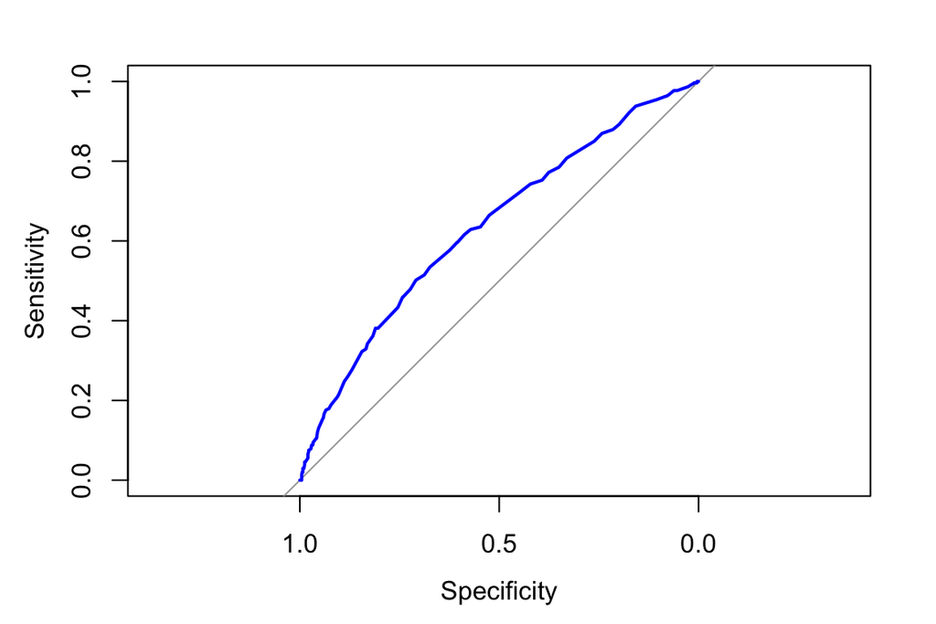

```r
fit1.roc <- roc(hd_data.f$HD, fit1$fitted, plot=T, col="blue")
```

```r
#fit1.roc <- roc(hd_data.f$HD, fit1, plot=T, col="blue")
```

- The ROC reports how well your classifier does at predicting y. The y-axis contains sensitivity (or true positive rate), whereas in this case, the x-axis contains specificity (or true negatve rate), and the blue line represents the tradeoff between the two for your classifier.
- One can use the ROC curve to determine a threshold for your classifier. For example, let’s say you want to select a value for your classifier SBP that would yield a false positive (FP) rate of 0.10. In this case, you go to specificity = 0.9 on your x-axis and can follow the blue line to deterimne the corresponding true positive (TP) rate for your model.
- If we were to specify our classifier such that FP < 0.1 an TP is as high as possible:

```r
# Select thresholds where FP rate or 1-specificity is < 0.1
var1 <- fit1.roc$thresholds[1-fit1.roc$specificities < 0.1]
var1
```

```
##  [1] 0.2982114 0.3048720 0.3116153 0.3184394 0.3236021 0.3270730 0.3323220
##  [8] 0.3393760 0.3465020 0.3536976 0.3591322 0.3627798 0.3682866 0.3756744
## [15] 0.3831206 0.3906220 0.3962778 0.4000672 0.4057778 0.4134256 0.4211153
## [22] 0.4288434 0.4346596 0.4385494 0.4483179 0.4659760 0.4777853 0.4837072
## [29] 0.4916085 0.5034665 0.5153219 0.5271544 0.5467913 0.5663125 0.5931495
## [36] 0.6306259 0.6596802 0.6772407 0.6942211 0.7107897 0.7236149 0.7390850
## [43]       Inf
```

```r
#Out of these values, select which threshold also corresponds to maximum sensitivity or TP rate
var2 <- var1[which.max(fit1.roc$sensitivities)]
var2    #Threshold is P(Yhat = 1) > 0.2982114
```

```
## [1] 0.2982114
```

```r
#Now, predict the performance of your model
fit1.1 <- rep("0", 1406)   # prediction step 1: set up all values to be "0"
fit1.1[fit1$fitted > var2] <- "1"  # prediction step 2 to get a classifier
fit1.1 <- as.factor(fit1.1) # make this \hat y
fit1.1 <- ifelse(fit1$fitted > var2, "1", "0")  # alternative way to assign \hat y

#Make a confusion table
cm.1 <- table(fit1.1, hd_data.f$HD) # confusion matrix:
cm.1
```

```
##
## fit1.1   0   1
##      0 980 241
##      1 106  66
```

```r
#FP Rate (1 - specificity)
spec.1 <- cm.1[1,1]/sum(hd_data.f$HD == 0)
FP.1 <- 1-spec.1
FP.1                           #FP Rate = 0.098
```

```
## [1] 0.09760589
```

```r
#TP Rate (sensitivity)
sens.1 <- cm.1[2,2]/sum(hd_data.f$HD == 1)
sens.1                         #TP Rate = 0.215
```

```
## [1] 0.2149837
```

The threshold value identified was P(Y = 1) > 0.2982114, which yields a TP rate or sensitivity of 21.5% and a FP rate or 1-specificity of 9.8%

2. Overlay two ROC curves: one from `fit1`, the other from `fit2`. Does one curve always contain the other curve? Is the AUC of one curve always larger than the AUC of the other one? Why or why not?

First, we find the ROC for fit2:

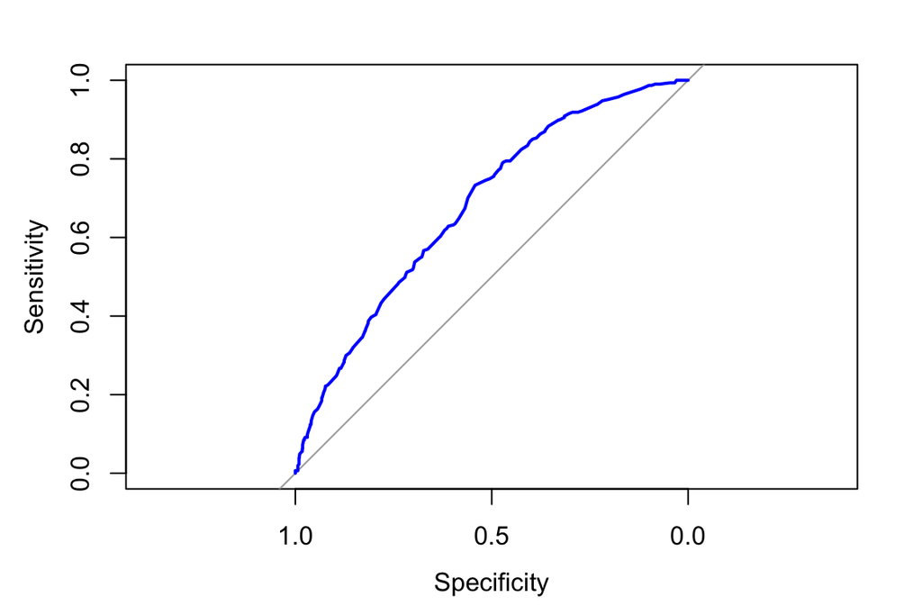

```r
fit2.roc <- roc(hd_data.f$HD, fit2$fitted, plot=T, col="blue")
```

Next, we plot fit1 in bue and fit2 in red:

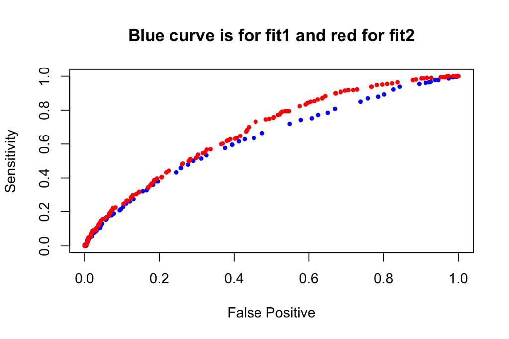

```r
plot(1-fit1.roc$specificities, fit1.roc$sensitivities, col="blue", pch=16, cex=.7,
     xlab="False Positive",
     ylab="Sensitivity")
points(1-fit2.roc$specificities, fit2.roc$sensitivities, col="red", pch=16, cex=.7)
title("Blue curve is for fit1 and red for fit2")
```

As we can see, fit2’s AUC contains fit1’s AUC. The AUC for fit2 always contains the AUC for fit1 because it includes the variables contained in fit1.

3. Estimate the Positive Prediction Values and Negative Prediction Values for `fit1` and `fit2` using .5 as a threshold. Which model is more desirable if we prioritize the Positive Prediction values?

To estimate the positive and negative predictive values for fit1 and fit2 with a threshold of 0.5, we execute the following code:

```r
#For fit1:
fit1.5 <- rep("0", 1406)
fit1.5[fit1$fitted > 0.5] <- "1"
fit1.5 <- as.factor(fit1.5)
cm.1.5 <- table(fit1.5, hd_data$HD)
pos.pred.1.5 <- cm.1.5[2, 2] / (cm.1.5[2, 1] + cm.1.5[2, 2])
neg.pred.1.5 <- cm.1.5[1, 1] / (cm.1.5[1, 1] + cm.1.5[1, 2])

#For fit2:
fit2.5 <- rep("0", 1406)
fit2.5[fit2$fitted > 0.5] <- "1"
fit2.5 <- as.factor(fit2.5)
cm.2.5 <- table(fit2.5, hd_data$HD)
pos.pred.2.5 <- cm.2.5[2, 2] / (cm.2.5[2, 1] + cm.2.5[2, 2])
neg.pred.2.5 <- cm.2.5[1, 1] / (cm.2.5[1, 1] + cm.2.5[1, 2])

#Print out desired variables
cm.1.5
```

```
##
## fit1.5    0    1
##      0 1081  305
##      1   14    6
```

```r
pos.pred.1.5
```

```
## [1] 0.3
```

```r
neg.pred.1.5
```

```
## [1] 0.7799423
```

```r
cm.2.5
```

```
##
## fit2.5    0    1
##      0 1073  297
##      1   22   14
```

```r
pos.pred.2.5
```

```
## [1] 0.3888889
```

```r
neg.pred.2.5
```

```
## [1] 0.7832117
```

For fit1 (threshold > 0.5): - Positive predictive value = 0.3000 - Negative predictive value = 0.7799 For fit2 (threshold > 0.5):  
- Positive predictive value = 0.3889 - Negative predictive value = 0.7832

Thus, if we prioritize positive predictive values, fit2 would be the more desirable model.

4. (Optional/extra credit) For `fit1`: overlay two curves, but put the threshold over the probability function as the x-axis and positive prediction values and the negative prediction values as the y-axis. Overlay the same plot for `fit2`. Which model would you choose if the set of positive and negative prediction values are the concerns? If you can find an R package to do so, you may use it directly.

### Part 3 - Bayes Rule

Bayes rules with risk ratio $\frac{a_{10}}{a_{01}}=10$ or $\frac{a_{10}}{a_{01}}=1$. Use your final model obtained from 1 B) to build a class of linear classifiers.

1. Write down the linear boundary for the Bayes classifier if the risk ratio of $a_{10}/a_{01}=10$.

Given that $\frac{a_{01}}{a_{10}}=\frac{1}{10}=0.1$ and the following equation:
$$P(Y=1 \vert x) > \frac{\frac{a_{0,1}}{a_{1,0}}}{1 + \frac{a_{0,1}}{a_{1,0}}}$$
We obtain that:
$$prob(Y=1 \vert x) > \frac{0.1}{(1+0.1)}=0.091$$
$$logit > \log(\frac{0.091}{0.909})=-2.301$$
Therefore, the linear boundary will be given by:
$$-9.228 + 0.062 \times AGE + 0.911 I_{Male} + 0.016 \times SBP + 0.004 \times CHOL + 0.006 \times FRW + 0.012 \times CIG \geq -2.301$$
After grouping all constants:
$$0.062 \times AGE + 0.911 I_{Male} + 0.016 \times SBP + 0.004 \times CHOL + 0.006 \times FRW + 0.012 \times CIG \geq 6.927$$

2. What is your estimated weighted misclassification error for this given risk ratio?

To calculate this error, we employ the following code:

```r
fit.exh.pred.bayes <- rep("0", 1406)
fit.exh.pred.bayes[fit.exh$fitted > .091] = "1"
MCE.bayes = (sum(10*(fit.exh.pred.bayes[hd_data$HD == "1"] != "1"))
           + sum(fit.exh.pred.bayes[hd_data$HD == "0"] != "0"))/length(hd_data$HD)
MCE.bayes
```

```
## [1] 0.8285917
```

Thus, the MCE for the Bayes Rule with $\frac{a_{10}}{a_{01}}=10$ is 0.8286.

3. Recall Liz, our patient from part 1. How would you classify her under this classifier?

Because Liz had $P(Y=1 \vert x) = 0.0496$, she would be classified as $HD = 0$ (or no heart disease since the condition $P(Y=1 \vert x) \geq 0.091$ was not met).

Now, draw two estimated curves where x = posterior threshold, and y = misclassification errors, corresponding to the thresholding rule given in x-axis.

4. Use weighted misclassification error, and set $a_{10}/a_{01}=10$. How well does the Bayes rule classifier perform?
5. Use weighted misclassification error, and set $a_{10}/a_{01}=1$. How well does the Bayes rule classifier perform?

To answer both d and e, we generate the following plot:

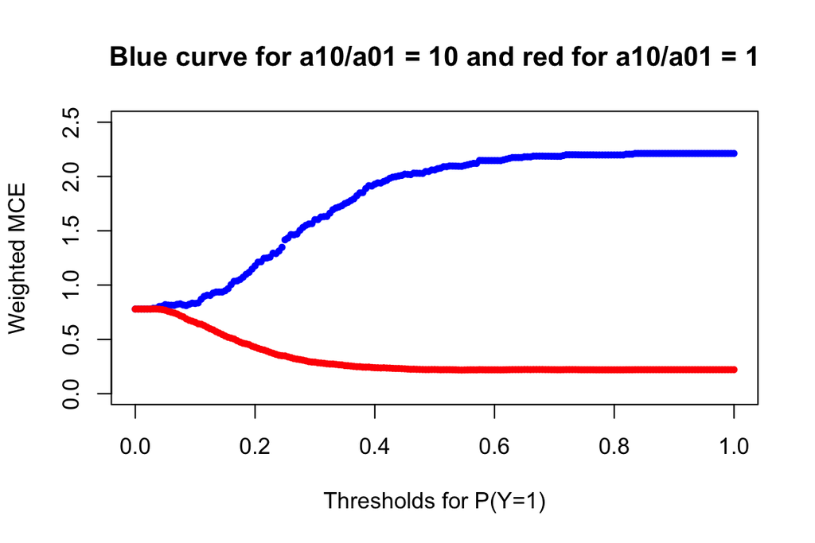

```r
#Generate vector with evenly spaced threshold values for P(Y=1)
thresholds <- seq(0,1,length=201)
l <- length(thresholds)
#For each value in the vector, calculate the weighted MCE given a_10/a_01 = 10
mce.vector.10 <- matrix(0,1,201)
for (i in 1:l) {
  fit.exh.pred.bayes <- rep("0", 1406)
  fit.exh.pred.bayes[fit.exh$fitted > thresholds[i]] = "1"
  MCE.bayes = (sum(10*(fit.exh.pred.bayes[hd_data$HD == "1"] != "1"))
           + sum(fit.exh.pred.bayes[hd_data$HD == "0"] != "0"))/length(hd_data$HD)
  mce.vector.10[i] <- MCE.bayes
}
#For each value in the vector, calculate the weighted MCE given a_10/a_01 = 1
mce.vector.1 <- matrix(0,1,201)
for (i in 1:l) {
  fit.exh.pred.bayes <- rep("0", 1406)
  fit.exh.pred.bayes[fit.exh$fitted > thresholds[i]] = "1"
  MCE.bayes = (sum(1*(fit.exh.pred.bayes[hd_data$HD == "1"] != "1"))
           + sum(fit.exh.pred.bayes[hd_data$HD == "0"] != "0"))/length(hd_data$HD)
  mce.vector.1[i] <- MCE.bayes
}
#Plot both, a_10/a_01 = 10 in blue, a_10,a_01 = 1 in red
plot(thresholds, mce.vector.10, col="blue", pch=16, cex=.7,
     xlab="Thresholds for P(Y=1)",
     ylab="Weighted MCE",
     xlim=c(0, 1),
     ylim=c(0, 2.5))
points(thresholds, mce.vector.1, col="red", pch=16, cex=.7)
title("Blue curve for a10/a01 = 10 and red for a10/a01 = 1")
```

## Problem 2

#### Project Goal

Laws. They govern almost every facet of our daily life: education, environment, health, business, intfrastructure, etc. They not only govern how we currently navigate in civil society, but affect future resources, laws, and outcomes as well. Since 2009 over 25,000 bills have been introduced in the state of Pennsylvania ([source](https://legiscan.com/PA)). Despite this large number of bills introduced, only a fraction of those are enacted into law. For example, in the 2013-2014 season 3,998 bills were introduced in the House and Senate. Of those 3,998 only 369 (9.2%) became law ([source](http://www.post-gazette.com/news/politics-state/2016/05/31/In-Pennsylvania-legislature-bills-have-a-tendency-to-stall/stories/201605310086)). Given the weight these national and state mandates it would be helpful if we were able to discern the qualities of a successful bill in order to most wisely use limited government resources. This project seeks to address this issue by using data to build a model to predict whether a given bill introduced into the Pennsylvania House of Representatives will pass or not.

#### Summary of the data

The provided data had already been split into training and testing data. The training data consists of 15 variables across 7011 entries. With respect to overall data set characteristics, the data come from sessions as far back as 2009 and as recently as 2014. Deciding factors in the outcome of the bill - such as party sponsor, number of co-sponsors, originating committee, etc. - will be used as variables and occupy their own column.

The outcome we are looking to explain is if the bill passed the House or not. This information can be found in the `status` column. Any of the following statuses correspond to a ‘passing’ bill: `Bill:passed`, `governor:signed`, or `governor:received`.

After assigning a value of 1 to all passing statuses and 0 to all non-passing states there are 455 passing bills and 6192 proposed non-passing ones, or roughly 7%. This is in line with the figures discussed above.

From the summary data, there are several other factors whose ranges and values are worth noting. Specifically, these values are sponsor party, number of co-sponsors, title word count, and originating committee.

##### Sponsor party

```
##    0    1
## 3579 3068
```

##### Number of co-sponsors

```
##    Min. 1st Qu.  Median    Mean 3rd Qu.    Max.
##    0.00   11.00   19.00   23.29   31.00  165.00
```

##### Title word count

```
##    Min. 1st Qu.  Median    Mean 3rd Qu.    Max.
##    6.00   22.00   27.00   34.13   34.00  751.00
```

The average number of words in bill titles is ~34, though some have as little as 6, while others have as many as 751!

##### Originating committee

```
## PAC000001 PAC000004 PAC000005 PAC000007 PAC000008 PAC000010 PAC000012
##       648      1031       211       327       202       277       800
## PAC000015 PAC000016 PAC000017 PAC000019 PAC000035 PAC000040 PAC000099
##        86       614       517       153        93       154       108
## PAC000129 PAC000141 PAC000165 PAC000190 PAC000215 PAC000229 PAC000244
##       266       218        12       114        39       143       160
## PAC000246 PAC000263 PAC000264 PAC000265
##       113       116       185        60
```

1. Aging & Older Adult Services
2. Agriculture & Rural Affairs
3. Appropriations
4. Children & Youth
5. Commerce
6. Committee On Committees
7. Committee On Ethics
8. Consumer Affairs
9. Education
10. Environmental Resources & Energy
11. Finance Representative
12. Game & Fisheries
13. Gaming Oversight
14. Health
15. Human Services
16. Insurance
17. Judiciary
18. Labor & Industry
19. Liquor Control
20. Local Government
21. Professional Licensure
22. Rules
23. State Government
24. Tourism & Recreational Development
25. Transportation
26. Urban Affairs
27. Veterans Affairs & Emergency Preparedness

### Building a classifier

We start by examining how all of the features are related to bill passage.

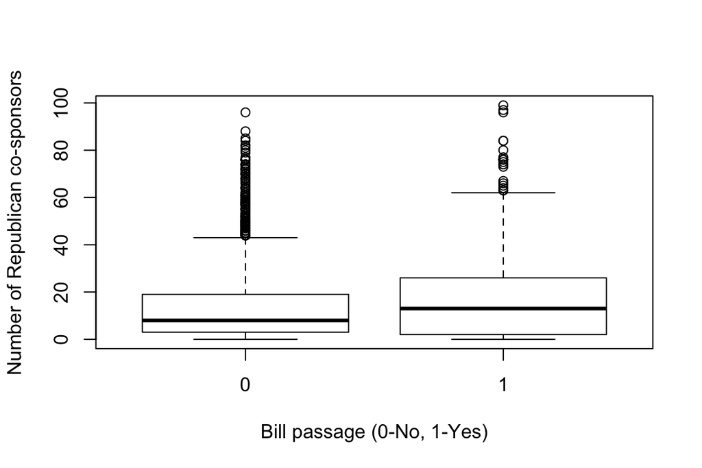

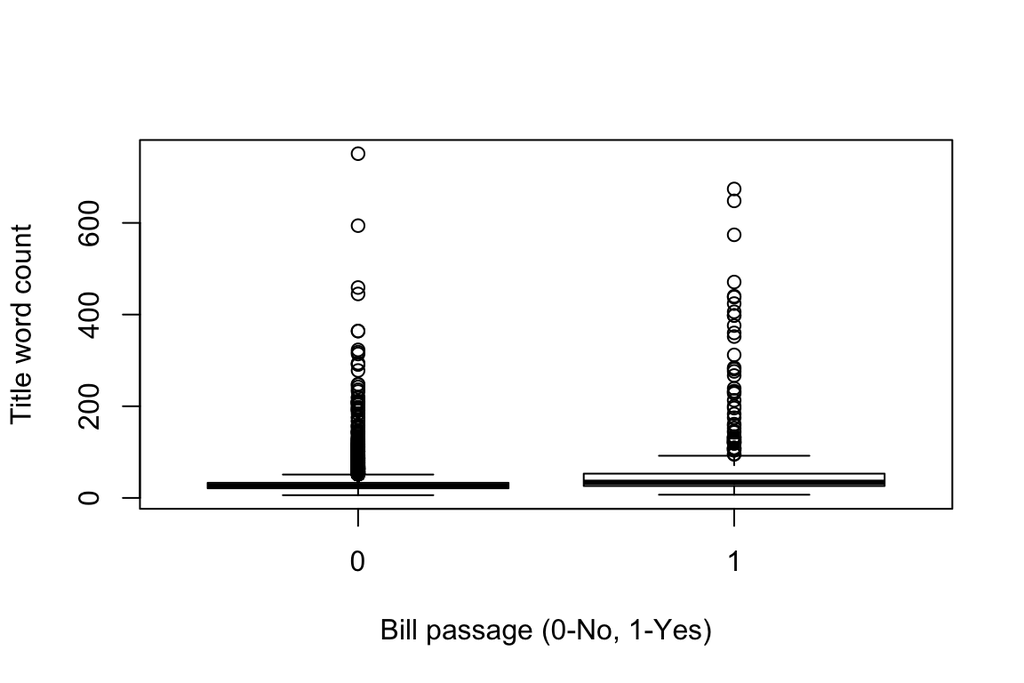

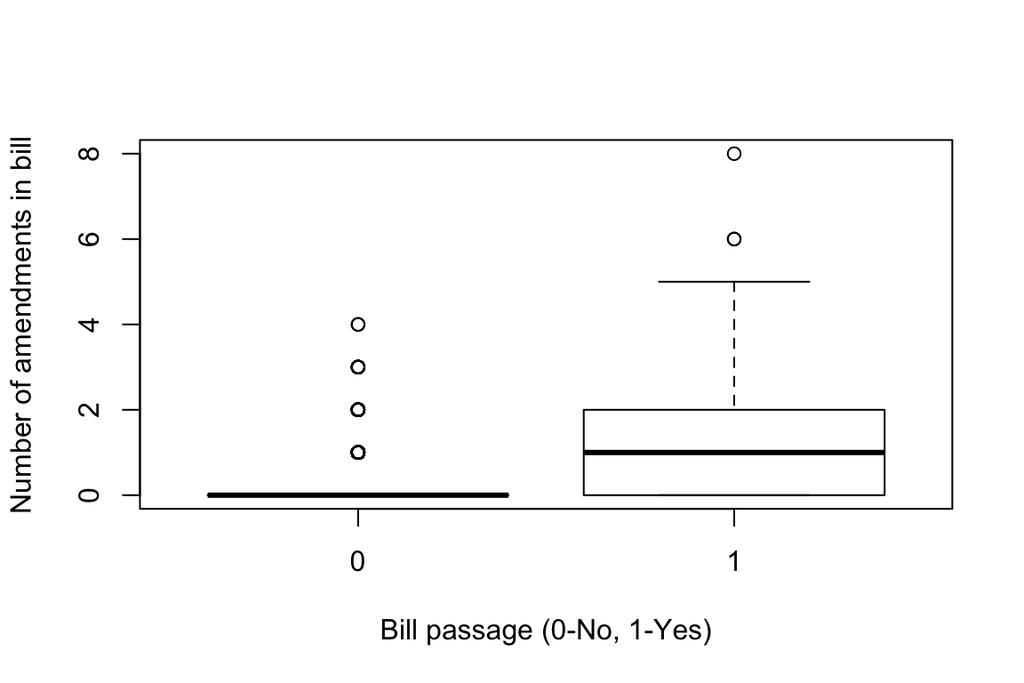

**These boxplots illustrate these main points:** average number of Republican cosponsors is 50% more on passing bills, average words in passing bills is double that in non-passing ones, and average number of amendments in non-passing bills is close to zero, while the average amendments for passing bills is slightly above 1.

The next step in building a classifier is performing logistic regression on the possible variables.

Choosing the most important variable to add using the criteria highest $|z|$ value or smallest $p$ value we choose the one with a combination of high $|z|$ values and small $p$ values: title word count (though number of amendments, number of originating cosponsors on bill committtee, number of republican sponsors sitting on referred committee, number of Republican sponsors, and sponsor party all had similar salient values). It should also be noted that number of amendments results in the lowest AIC by a wide margin.

The variable is significant at the .001 level. Title word count has $p$ values of 1.28e-06 and < 2e-16 for Wald Test/Chi-squared test (respectively).

Lastly we get a prediction from this model by using a random row from the data that was reserved for testing.

```
##      7854
## 0.0378811
```

#### Model exploration

The two classifiers we came up with are `bill.fit1.0.0`, using logistic regression with just `title_word_count`, and `bill.fit.full`, using logistic regression with `sponsor_party`, `num_r_cosponsors`, `title_word_count`, `num_amendments`, and `num_originating_committee_cosponsors`.

### Classifier 1

Using a threshold probability of 2/3, we can plug values in to the estimated probability. Thus, we will classify a bill being $Y=1$ (passing) if:

$$\hat Y=1 ~~~~ \text{if} ~~~~ \frac{e^{-3.057+.01117\cdot title\_word\_count}}{1+e^{-3.057+.01117\cdot title\_word\_count}} > \frac{2}{3}.$$
$$\hat Y=1 ~~~~ \text{if} ~~~~ title\_word\_count > \frac{\log(2)+3.057}{.01117}=335.73$$
And using a threshold of 1/2:

$$\hat y = 1 ~~~~ \text{if} ~~~~ title\_word\_count > \frac{3.057}{0.01117}=273.68$$

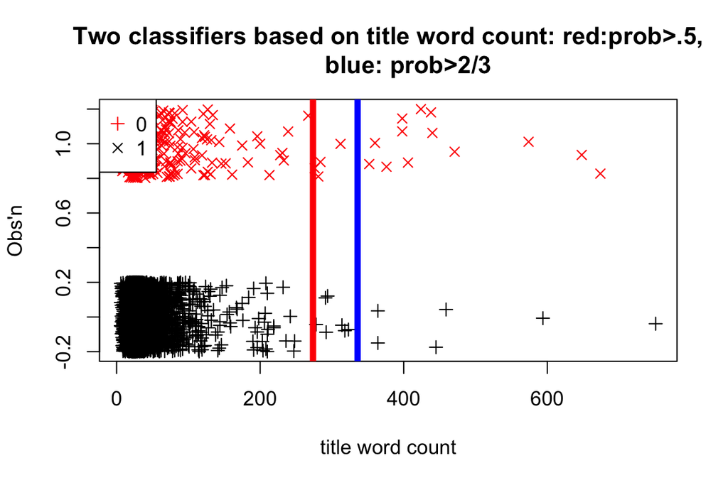

Evaluating the 2/3 threshold produces the following important evaluation criteria:

```
        Sensitivity : 0.99903
        Specificity : 0.02857
     Pos Pred Value : 0.93331
     Neg Pred Value : 0.68421
```

The second rule (threshold 1/2) produced the following evaluation criteria:

```
        Sensitivity : 0.99790
        Specificity : 0.03736
     Pos Pred Value : 0.93381
     Neg Pred Value : 0.56667
```

And then comparing ROC curve and AUC:

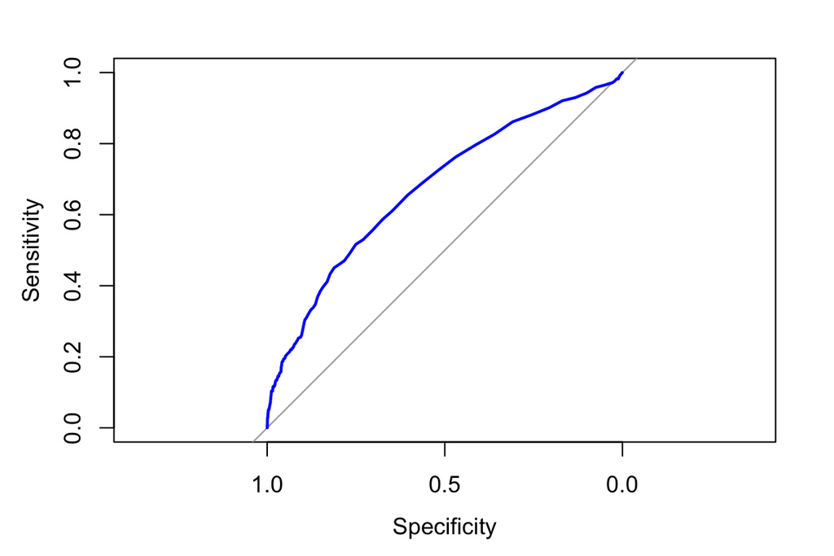

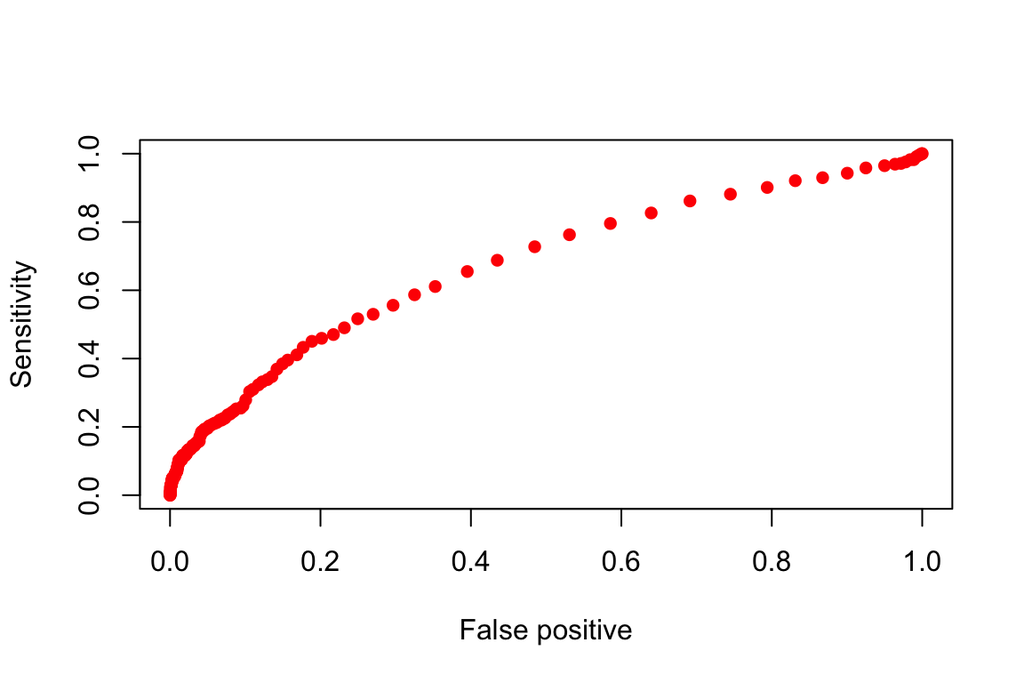

```
## Area under the curve: 0.6761
```

### Classifier 2

For threshold of 2/3:

$$\hat Y = 1\space if\space title\_word\_count > 164.79 \cdot sponsor\_party - 363.75 \cdot num\_amendments - 9.646 \cdot num\_originating\_committee\_cosponsors + 841.906$$

For threshold of 1/2:

$$\hat Y = 1\space if\space title\_word\_count > 164.79 \cdot sponsor\_party - 363.75 \cdot num\_amendments - 9.646 \cdot num\_originating\_committee\_cosponsors + 697.5$$
Then plotting both lines:

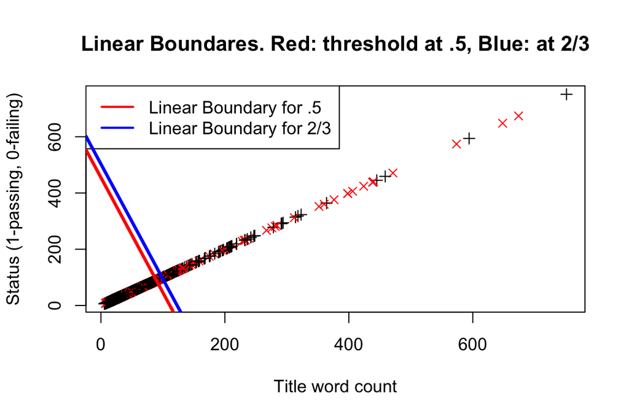

And then obtaining sensitivity, specificity, ROC curve & AUC values:

Threshold 2/3:

```
        Sensitivity : 0.9973
        Specificity : 0.1604
     Pos Pred Value : 0.9417
     Neg Pred Value : 0.8111
```

Threshold 1/2:

```
        Sensitivity : 0.9927
        Specificity : 0.2593
     Pos Pred Value : 0.9480
     Neg Pred Value : 0.7239
```

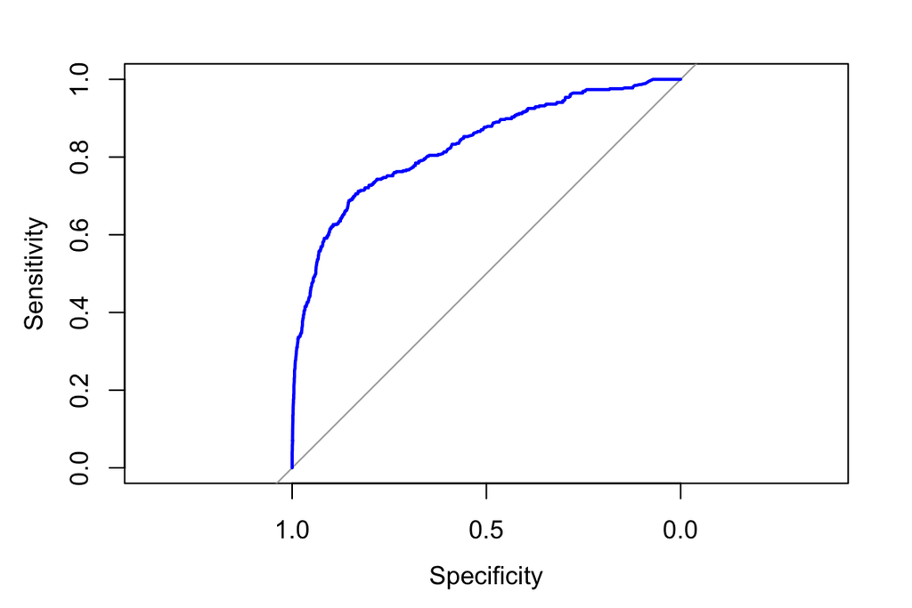

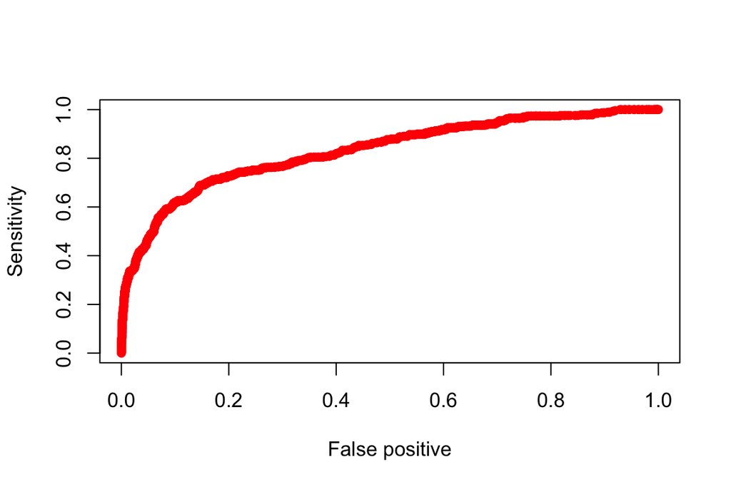

```
## Area under the curve: 0.8302
```

Up to this point we used logistic regression to come up with 2 possible classifiers: `bill.fit1.0.0`, with just `title_word_count`, and `bill.fit.full`, using logistic regression with `sponsor_party`, `num_r_cosponsors`, `title_word_count`, `num_amendments`, and `num_originating_committee_cosponsors`. Variables were chosen on the robustness of $|z|$ and $p$ values.

We then established 2 rules for each classifier and individually investigated their performance via the following criteria: sensitivity, specificity, positive prediction value, negative prediction value, ROC curve and AUC. The last step is to choose one of the models by comparing these two classifiers side by side, along with 1 other classifier- classifier 3: `bill.fit1.0.1` - whose independent variable `num_amendments` performed as well as `title_word_count` in terms of $|z|$ and $p$.

### Choosing the best classifier using testing data

We are going to compare ROC curves in order to estimate the quality of our classifiers(`bill.fit1.0.0` - 1 var. `title_word_count`; `bill.fit1.0.1` 1 var. `num_amendments`; `bill.fit.full` - 5 vars. `sponsor_party`, `num_r_cosponsors`, `title_word_count`, `num_amendments`, and `num_originating_committee_cosponsors`).

```
##      bill.fit1.0.0.test bill.fit1.0.1.test bill.fit.full.test
## 6397         0.06233997          0.0333014         0.01818455
## 6310         0.05494977          0.0333014         0.04432042
## 6025         0.06568536          0.0333014         0.01861973
## 7914         0.05731657          0.0333014         0.01750895
## 7335         0.05494977          0.0333014         0.04056120
## 5964         0.06040976          0.0333014         0.03371970
## 7564         0.05731657          0.0333014         0.01832310
## 6954         0.05977888          0.0333014         0.04598215
## 6893         0.05671605          0.0333014         0.01996987
## 7458         0.05853559          0.0333014         0.04556124
## 7099         0.06500319          0.0333014         0.02029260
## 7904         0.06104687          0.0333014         0.04440120
## 5772         0.05977888          0.0333014         0.01867303
## 7856         0.05853559          0.0333014         0.03989066
## 7941         0.06169025          0.1789987         0.30803021
## 6279         0.05612144          0.0333014         0.03745435
## 7418         0.08417947          0.1789987         0.24460704
## 6263         0.05323539          0.0333014         0.04181794
## 7028         0.05915417          0.0333014         0.04007562
## 7569         0.05915417          0.0333014         0.02228018
```

Seeing the 3 classifiers side by side we can see their $\hat Y$ values vary. We plot their ROC curves on the same graph to compare them.

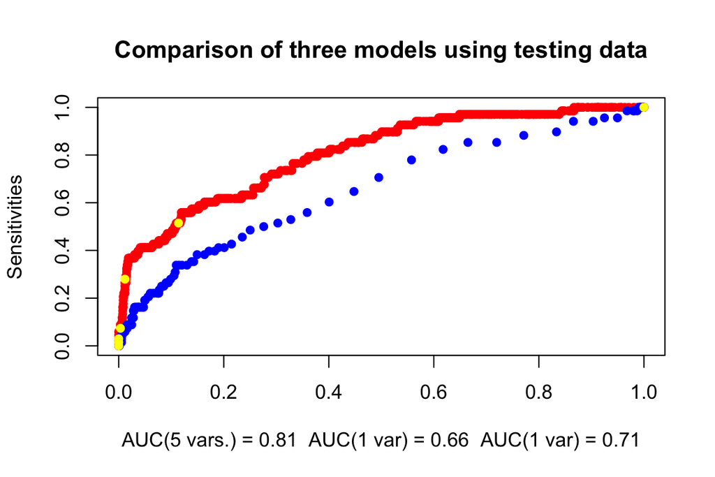

`bill.fit.full.test` - red | `bill.fit1.0.0.test` - blue | `bill.fit1.0.1.test` - yellow

As the overlaid ROC curves show, the classifier with 5 variables is the one that performs the best. It has the highest AUC at .81.

By using both training (6647 entries after cleaning) and testing (1000 randomly chosen entries) data we were able to avoid overfitting the models and also using the test data to compare the quality of the classifiers, leading us to choose classifier 2 (`bill.fit.full`).

#### Suggestions

**4. Suggestions you may have: what important features should have been collected which would have helped us to improve the quality of the classifiers.**

It would be good to have more descriptive/content information in general to improve the quality of the classifiers. For example, the knowing which originating committee values correspond to the dataset entries could supply insight on which areas of government pass most bills, and consequently what type of bills are more likely to pass. Moreover, what is most lacking from this set of features are values that speak to the *content* of the bills. Number of words in title attempts to serve as a stand in for complexity, severity, and/or robustness of a proposal, though this is hardly a reasonable assumption. For starters running a sentiment analysis on the text of the proposed bills could tag them as either “positive” or “negative” in tone, a factor that may influence their outcome. Access and similar analysis of public opinion pieces and articles about these bills would also help in this regard. Text analysis like this could also speak to the complexity of the bill in terms of vocabulary. Similarly, by using word frequency analysis removing [stop words](http://xpo6.com/list-of-english-stop-words/) we could ascertain several key tags for texts and have categorical columns/values for them (ie “education”, “infrastructure”, “public health”, etc.). Additionally, the timing of when the bill was introduced (in the session) might be a telling value to have, as timing is purported to affect legislative outcomes ([source 1](https://fiscalnote.com/2016/03/02/three-legislative-factors-that-lead-to-efficient-bill-passage/), [source 2](https://www.questia.com/library/journal/1G1-241861882/factors-of-influence-on-legislative-decision-making)). It is also worth noting that source 1 shows that Pennsylvania as a state is has near the lowest passing rate at 7% (which further confirms our findings above), and is only behind NJ (5.3%), MN (4.2%), and CT (1.6%). The state with the highest passing rate is Colorado which has and average enacted rate at 63.4%. Topics for further investigation include attempting to find the differences between these two states that lead to these outcomes.

*Final notes*: The data is graciously lent from a friend. It is only meant for you to use in this class. All other uses are prohibited without permission.